# Yusuf Emre Kilicer

Possible points: **45**

Available time: **90** minutes

```r
#List libraries you will use for solving tasks

library(tidyverse)
library(lubridate)
library(ggplot2)
```

At the end, **you must render the document to html**! Otherwise 25 % of reached points will be deducted.

# Tasks

## Task 1 (6 points)

Import data about tuition costs and perform the following tasks:

- Show the structure of the DataFrame.
- Display the data type of each column using `sapply`.
- Determine how many columns are numeric and how many are strings.
- Perform exploratory data analysis (EDA) using the `skimr` package.

```r
tuition_cost <- readr::read_csv("https://raw.githubusercontent.com/rfordatascience/tidytuesday/master/data/2020/2020-03-10/tuition_cost.csv")

tuition_cost %>% DT::datatable(caption ="Data Frame", options = list(
   pageLength = 5,
   autoWidth =TRUE
))
```

|  | name | state | state_code | type | degree_length | room_and_board | in_state_tuition | in_state_total | out_of_state_tuition | out_of_state_total |
| --- | --- | --- | --- | --- | --- | --- | --- | --- | --- | --- |
| 1 | Aaniiih Nakoda College | Montana | MT | Public | 2 Year |  | 2380 | 2380 | 2380 | 2380 |
| 2 | Abilene Christian University | Texas | TX | Private | 4 Year | 10350 | 34850 | 45200 | 34850 | 45200 |
| 3 | Abraham Baldwin Agricultural College | Georgia | GA | Public | 2 Year | 8474 | 4128 | 12602 | 12550 | 21024 |
| 4 | Academy College | Minnesota | MN | For Profit | 2 Year |  | 17661 | 17661 | 17661 | 17661 |
| 5 | Academy of Art University | California | CA | For Profit | 4 Year | 16648 | 27810 | 44458 | 27810 | 44458 |
| 6 | Adams State University | Colorado | CO | Public | 4 Year | 8782 | 9440 | 18222 | 20456 | 29238 |
| 7 | Adelphi University | New York | NY | Private | 4 Year | 16030 | 38660 | 54690 | 38660 | 54690 |
| 8 | Adirondack Community College | New York | NY | Public | 2 Year | 11660 | 5375 | 17035 | 9935 | 21595 |
| 9 | Adrian College | Michigan | MI | Private | 4 Year | 11318 | 37087 | 48405 | 37087 | 48405 |
| 10 | Advanced Technology Institute | Virginia | VA | For Profit | 2 Year |  | 13680 | 13680 | 13680 | 13680 |

[output cut: 2963 more lines]

```r
my_funct <- function(x){
  return (class(x))

}


sapply(tuition_cost, my_funct)
```

```
                name                state           state_code
         "character"          "character"          "character"
                type        degree_length       room_and_board
         "character"          "character"            "numeric"
    in_state_tuition       in_state_total out_of_state_tuition
           "numeric"            "numeric"            "numeric"
  out_of_state_total
           "numeric"
```

```r
numeric_col <- sum(sapply(tuition_cost, is.numeric))
string_col <- sum(sapply(tuition_cost, is.character))

paste("Total numeric is " , numeric_col)
```

```
[1] "Total numeric is  5"
```

```r
paste("Total string  is " , string_col)
```

```
[1] "Total string  is  5"
```

```r
paste(ncol(tuition_cost == numeric_col + string_col))
```

```
[1] "10"
```

```r
#I coulndt download the skimr
#skimr::skim(tuition_cost)
```

## Task 2 (6 points)

Using the “tuition_cost” dataset, display the name of the state and its abbreviation/code, along with the number of colleges (name variable). The United States has 50 states, so exclude any incorrect rows. Identify the 5 states with the highest number of colleges and display them in a chart (x-axis: state, y-axis: number of colleges).

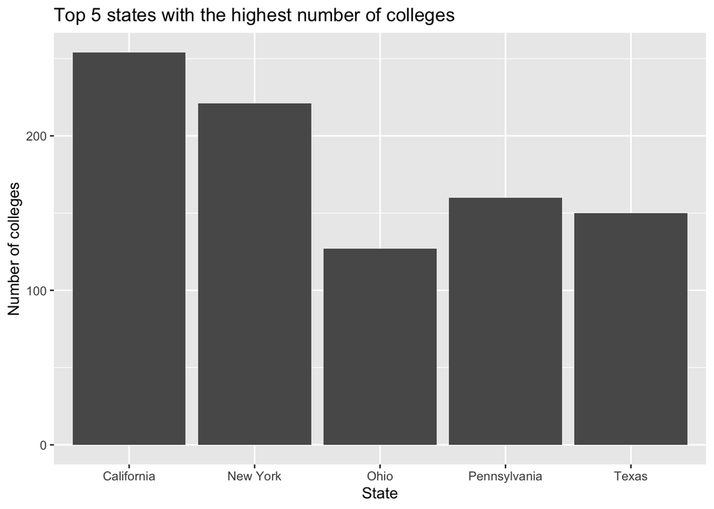

```r
top_5_data <- tuition_cost %>%
  filter(!is.na(state)) %>%
  select(state, name) %>%
  group_by(state) %>% summarise(n = n()) %>%
  arrange(desc(n)) %>%
  head(5)

  ggplot(top_5_data,aes(x = state, y = n)) +
    geom_col() +
    labs(title = "Top 5 states with the highest number of colleges",
         x = "State",
         y = "Number of colleges")
```

## Task 3 (6 points)

Install the `janeaustenr` package and read the books into a `booksDF` dataframe. Determine how many times the words “Darcy”, “Henry Tilney”, and “Admiral Baldwin” appear.

Create a dataframe `austenDF` with two columns:

- “character” containing values “Darcy”, “Henry Tilney”, and “Admiral Baldwin”.
- “frequency” containing the corresponding word frequencies.

Display the `austenDF` dataframe in `gt` format.

```r
library(janeaustenr)

booksDF <- austen_books()

colnames(booksDF)
```

```
[1] "text" "book"
```

```r
austenDF <- booksDF %>%
  count(book) %>%
  filter(book %in% c("Darcy", "Henry Tilney", "Admiral Baldwin")) %>% rename(character = book, frequency = n)

austenDF %>% gt::gt()
```

| character | frequency |
| --- | --- |

## Tasks 4 (5 points)

Convert the `grades` dataframe from long to wide format, with “math” and “history” as the new columns. Display the wide format. Then, transform it back to the original long format and display it. Calculate the average grade for math and history using `tidyverse` syntax.

```r
grades <- data.frame(names = c("John", "Juan", "Jean", "Yao","John", "Juan", "Jean", "Yao"), variable=c("math","math","math","math","history","history","history","history"), values=c(95, 80, 90, 85, 90, 85, 85, 90))



grades_wide <- grades %>% pivot_wider(names_from = variable, values_from = values)

grades_wide %>% knitr::kable()
```

| names | math | history |
| --- | --- | --- |
| John | 95 | 90 |
| Juan | 80 | 85 |
| Jean | 90 | 85 |
| Yao | 85 | 90 |

```r
avg_math <- grades_wide %>% select(math) %>% sum() / nrow(grades_wide)


avg_history <-grades_wide %>% select(history) %>% sum() / nrow(grades_wide)

avg_math
```

```
[1] 87.5
```

```r
avg_history
```

```
[1] 87.5
```

## Task 5 (5 points)

Write a function in R to find the longest word in a given sentence. Example: `find_longest_word("R is a great language for data analysis")` should return `c("analysis", "language")`.

```r
find_longest_word <- function(sentence){

  words <- unlist(strsplit(sentence, " "))

  max_length <- max(nchar(words))

  words[ max_length == nchar(words)]


}


find_longest_word("R is a great language for data analysis")
```

```
[1] "language" "analysis"
```

## Task 6 (4 points)

Import the `Cars.csv` file into the `carsDF` variable. Using the `tidyverse` approach, show the number of rows by year (extract the year from the `dateCrawled` column) where the car name starts with “M” and ends with a number. Hint: Use `str_extract` in the filter to apply the regular expression.

```r
carsDF<-read.csv("https://raw.githubusercontent.com/urosgodnov/datasets/master/Cars.csv")

carsDF %>% mutate(year = year(dateCrawled)) %>% filter(str_detect(name, "^M.*[0-9]$")) %>% count(year)
```

```
  year  n
1 2016 21
```

## Task 7 (5 points)

Add a new column called “WeekDay_lastseen” to the `carsDF` dataframe. This column should contain the full name of the day based on the “lastSeen” column.

```r
library(tidyverse)

carsDF <- carsDF %>% mutate(WeekDay_lastseen = wday(lastSeen,abbr =FALSE,label = TRUE))


carsDF %>% select(lastSeen ,WeekDay_lastseen) %>% DT::datatable(options = list(
  pageLength = 5,
  autoWidth = TRUE
))
```

|  | lastSeen | WeekDay_lastseen |
| --- | --- | --- |
| 1 | 2016-03-12 22:44:42 | Saturday |
| 2 | 2016-03-17 13:15:57 | Thursday |
| 3 | 2016-04-06 14:44:56 | Wednesday |
| 4 | 2016-04-07 02:46:32 | Thursday |
| 5 | 2016-04-05 19:44:52 | Tuesday |
| 6 | 2016-04-05 14:44:53 | Tuesday |
| 7 | 2016-04-05 05:17:33 | Tuesday |
| 8 | 2016-03-11 10:36:24 | Friday |
| 9 | 2016-04-07 01:45:59 | Thursday |
| 10 | 2016-03-20 13:36:24 | Sunday |

[output cut: 990 more lines]

## Task 8 (5 points)

Using the `carsDF` dataframe, create a scatter plot in `ggplot2` with:

- x-axis: price
- y-axis: powerPS

Ensure the x-axis scale is appropriate. Add facets by `fuelType` (only for benzin, diesel, lpg). Add a chart title and a horizontal line. Ensure the chart looks nice by applying a theme and adjusting the space and scales in facets.

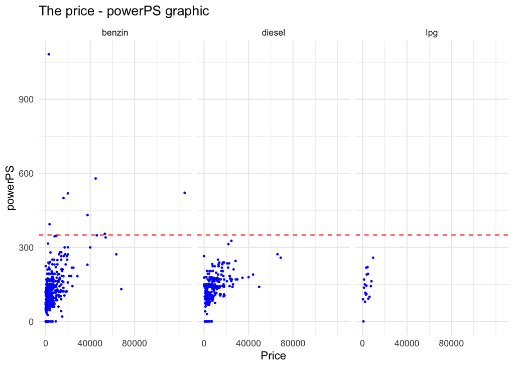

```r
 carsDF %>% filter(fuelType=="benzin" | fuelType =="lpg" | fuelType =="diesel") %>%
 ggplot(aes(x = price, y = powerPS)) +
  geom_jitter(size = 0.5,color ="blue") +
   scale_x_continuous(breaks = seq(0,80000,by = 40000))+
  facet_wrap(~fuelType) +
   geom_hline(yintercept = 350, linetype = "dashed",color ="red")+
   labs(
     title = "The price - powerPS graphic",
     x = "Price",
     y= "powerPS"
   )+theme_minimal()
```

## Task 9 (3 points)

Calculate the difference in seconds between the following two dates:

```r
x <- "11th april 2012 14:21:24"
y <- "May 24th 2024 11:59:59"

datex <-as.POSIXct(x , format="%dth %b %Y %H:%M:%S")
datex
```

```
[1] "2012-04-11 14:21:24 CEST"
```

```r
datey <- as.POSIXct(y , format = "%b %dth %Y %H:%M:%S")
datey
```

```
[1] "2024-05-24 11:59:59 CEST"
```

```r
time_difference <-difftime(datey,datex,units = "secs")

paste("The time difference is ",time_difference)
```

```
[1] "The time difference is  382397915"
```